# Aiming a Spinner is Difficult

## Abstract

A spinner was constructed that would produce a standard uniform distribution if spun randomly. By carefully trying to spin half-spins or full-spins, I attempted to get a sample mean far enough from 0.5 to allow me to show the spins were not random. With 100 trials of each, I was able to do significantly better than chance with half-spins ($p$-value = 0.003) but not with full-spins ($p$-value = 0.13). This suggests that aiming a spinner is more difficult than I would have guessed, but certaintly possible under certain circumstances.

## Introduction

A spinner is one of the most iconic randomizing devices. Versions of spinners show up in television shows, such as *Wheel of Fortune* and *The Price is Right*. Spinners are also featured in a number of at-home games, such as *Twister* and *The Game of Life*.

As a Statistics teacher, I am interested in spinners as a way of displaying and discussing probability distributions and random variables. Spinners can depict categorical, discrete, and continuous random variables. It is easy to understand that larger areas have higher probabilities. I personally believe (without support) that a spinner is easier to understand than a probability density curve.

A potential drawback of spinners as metaphors for randomness is a spinner’s inherently deterministic behaviour. The initial velocity determines the final position, and (as far as I know) small variations in initial velocity do not have substantially different final positions (as is seen in more [chaotic](https://en.wikipedia.org/wiki/Chaos_theory) nonlinear systems like a [double pendulum](https://en.wikipedia.org/wiki/Double_pendulum)). However, a spinner with less friction will have more variation in final position with subtle differences in initial velocity.

The randomness of a spinner depends on the human’s inaccuracy in controlling the initial velocity. I was interested in how well I could control a spinner. Before any trials, I assumed I would be able to reliably spin the spinner $720^\circ \pm 45^\circ$.

## Method

All spins used a plastic spinner meant for educational purposes. It has two parts, a base and the 4-inch arrow. The arrow is weighted equally on either side of the base (about 2 inches on either side). The friction is low enough that getting 10 complete rotations is quite easy. When the arrow rests on the base, there is a vertical hole in the middle of both pieces, allowing precise alignment of the arrow in the middle of the printed demarcated circle (with a dot in the middle).

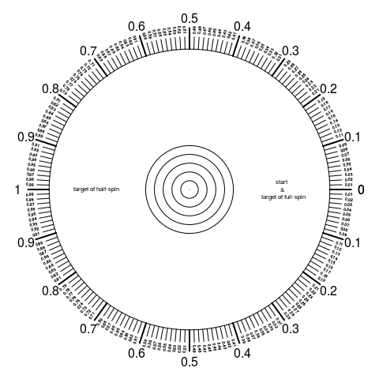

```r
{
par(mar=c(0,0,0,0))
plot(0,0,type='n',axes=F,ann=F,xlim=c(-1,1),ylim=c(-1,1))
thetas = seq(0,2*pi,length.out=2001)
polygon(0.8*cos(thetas),0.8*sin(thetas))
for(p in seq(0,0.25,0.05)){
  polygon(p*cos(thetas),p*sin(thetas))
}

for(theta in seq(0,2*pi,length.out=201)){
  lines(c(0.87*cos(theta),0.8*cos(theta)),c(0.87*sin(theta),0.8*sin(theta)))
  }

for(th in seq(0,2*pi,length.out=21)){
  lines(c(0.92*cos(th),0.8*cos(th)),c(0.92*sin(th),0.8*sin(th)),lwd=2)
  u = 1-abs(pi-th)/pi
  text(0.98*cos(th),0.98*sin(th),u)
}

for(i in 0:100){
  if(i%%10 != 0){
    text(cos(i/100*pi)*0.91,sin(i/100*pi)*0.91,i/100,cex=0.3,srt=((i/100*180)+90)%%180-90)
    text(cos(i/100*pi)*0.91,-sin(i/100*pi)*0.91,i/100,cex=0.3,srt=-((i/100*180)+90)%%180-90)
  }
}
text(0.53,0,"start \n & \n target of full-spin",cex=0.5)
text(-0.53,0,"target of half-spin",cex=0.5)
}
```

The spinner was taped to a printed copy of the circle above, and a few weights held the paper in place. The middle of the demarcated circle has a dot to align the spinner. This dot was also useful when reading the spins, because the arrow floated about 1 cm above the paper. Using one eye, I would first make sure the dot seemed centered in the hollow center of the arrow, and then I would determine the position of the tip of the arrow. This method reliably produced readings to the nearest 0.005.

Two sets of data were collected. I first started the arrow on the 0 and targeted the 1 with a half spin. Then, I started the arrow on the 0 and targeted the 0 with a full spin. Before the trials, I decided to do 100 spins of each type. Each set of data was analyzed with a two-tailed hypothesis test of the mean where the null hypothesis claimed the spins were uniformly distributed with mean 0.5 and standard deviation $\frac{1}{\sqrt{12}}$ (see continuous uniform distribution). I decided before the spins to use a significance level of 0.05.

The null hypothesis suggests that due to natural variation, the sampling distribution of the mean of 100 random spins should have a mean of 0.5 and a standard error of $\frac{1}{\sqrt{12}\sqrt{100}} \approx 0.0289$. This suggest that 95% of the time, 100 random spins should have a mean between $0.5-1.96\times0.0289 = 0.443$ and $0.5+1.96\times0.0289 = 0.557$.
$$H_0 ~\text{ claims }~ P(0.443 < \bar{x} < 0.557) = 0.95$$
So, if 100 spins produce a mean outside the interval [0.443,0.557], we will reject the null hypothesis.

## Results

The spins are summarized by the histograms below.

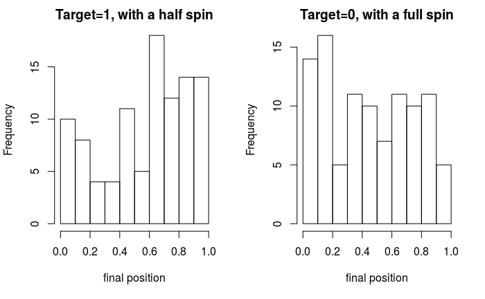

```r
spins = c(0.67, 0.885, 0.15, 0.76, 0.99, 0.71, 0.06, 0.24, 0.76, 0.68, 0.1, 0.67, 0.19, 0.23, 0.62, 0.71, 0.47, 0.62, 0.48, 0.075, 0.4, 0.485, 0.06, 0.485, 0.65, 0.97, 0.885, 0.51, 0.76, 0.87, 0.61, 0.47, 0.97, 0.92, 0.14, 0.99, 0.31, 0.545, 0.855, 0.72, 0.89, 0.705, 0.99, 0.02, 0.74, 0.63, 0.58, 0.2, 0.86, 0.99, 0.94, 0.85, 0.9, 0.35, 0.59, 0.53, 0.95, 0.81, 0.665, 0.46, 0.69, 0.99, 0.48, 0.95, 0.14, 0.61, 0.485, 0.62, 0.02, 0.15, 0.46, 0.35, 0.81, 0.92, 0.47, 0.885, 0.06, 0.69, 0.72, 0.76, 0.97, 0.65, 0.855, 0.63, 0.075, 0.705, 0.47, 0.67, 0.86, 0.2, 0.19, 0.03, 0.9, 0.99, 0.67, 0.68, 0.1, 0.24, 0.23, 0.76)
spins2 = c(0.18, 0.36, 0.58, 0.09, 0.675, 0.8, 0.1, 0.05, 0.92, 0.135, 0.65, 0.41, 0.75, 0.785, 0.845, 0.19, 0.905, 0.39, 0.775, 0.59, 0.775, 0.001, 0.485, 0.535, 0.85, 0.865, 0.61, 0.06, 0.845, 0.615, 0.245, 0.15, 0.41, 0.002, 0.13, 0.91, 0.47, 0.035, 0.615, 0.735, 0.73, 0.355, 0.97, 0.47, 0.065, 0.19, 0.12, 0.845, 0.475, 0.013, 0.305, 0.18, 0.265, 0.165, 0.32, 0.575, 0.04, 0.99, 0.58, 0.14, 0.895, 0.62, 0.82, 0.82, 0.89, 0.67, 0.79, 0.47, 0.86, 0.001, 0.38, 0.34, 0.5, 0.37, 0.15, 0.46, 0.7, 0.265, 0.165, 0.31, 0.39, 0.11, 0.05, 0.64, 0.36, 0.19, 0.55, 0.84, 0.02, 0.19, 0.29, 0.7, 0.51, 0.03, 0.13, 0.75, 0.71, 0.21, 0.43, 0.69)

par(mfrow=c(1,2))
hist(spins,breaks=10,main="Target=1, with a half spin",xlab="final position")
hist(spins2,breaks=10,main="Target=0, with a full spin",xlab="final position")
```

```r
mu0 = 0.5
sig0 = sqrt(1/12)

n = length(spins)
xbar = mean(spins)
z = (xbar-mu0)/sig0*sqrt(n)
pvalue = pnorm(-abs(z))*2

n2 = length(spins2)
xbar2 = mean(spins2)
z2 = (xbar2-mu0)/sig0*sqrt(n2)
pvalue2 = pnorm(-abs(z2))*2
```

Some values used for the hypothesis testing are shown below.

| Statistic | Half spin | Full spin |
| --- | --- | --- |
| $n$ | 100 | 100 |
| $\bar{x}$ | 0.585 | 0.456 |
| $z$ | 2.93 | -1.53 |
| $p$-value (two-tail) | 0.0034 | 0.13 |

We can reject the null hypothesis for the half-spins, but not for the full-spins.

We can also build 95% confidence intervals of both cases. For this we will use the sample standard deviations and the $t$ distribution.

$$CI ~=~ \left(\bar{x}-t^\star \frac{s}{\sqrt{n}}, ~ \bar{x}+t^\star \frac{s}{\sqrt{n}}\right)$$

```r
s = sd(spins)
df = n-1
tstar = qt(0.975,df)
lb = signif(xbar-tstar*s/sqrt(n),2)
ub = signif(xbar+tstar*s/sqrt(n),2)

s2 = sd(spins2)
df2 = n2-1
tstar2 = qt(0.975,df2)
lb2 = signif(xbar2-tstar2*s2/sqrt(n2),2)
ub2 = signif(xbar2+tstar2*s2/sqrt(n2),2)
```

In both cases, the degrees of freedom equals 99 and the confidence level is 95%, so $t^\star=1.98$. The sample standard deviations are 0.293 and 0.294. Thus, the 95% confidence interval for the half-spins mean is (0.53, 0.64), and the 95% confidence interval for the full-spin means is (0.4, 0.51). Notice the half-spins confidence interval does not contain 0.5, while the full-spin confidence interval does.

## Discussion

In the trials, I was able to do sigficantly better than chance in 100 spins only when targeting a half-spin. I was surprised by how difficult it was to aim the spinner toward a specific target. The data don’t show that when I tried a half-spin, I often spun over a full rotation, and when I tried a full-spin, I would often get more than 2 rotations or even less than a half rotation. In fact, I found it so frustrating that I didn’t even bother with any harder targets.

I am very interested to know if other people are more capable at aiming spinners. I imagine larger spinners with more friction could be easier. I am also interested to know under what circumstances people can bend the odds of flipping coins or rolling dice.